# individual1

1. How are the ratings distributed? Draw a histogram of the ratings and describe it. Don’t forget to mention outliers, if there are any.

The ratings are rated by its score and put into the respected bucket of the histogram. These ratings range from 0 to 5 with decimal points of .00, .25, .50, and .75 being part of classifying the buckets.

There are a few outliers in the histogram with ratings of 1s and 5s either not having any values or very little values. Another outlier worth mentioning is the rating from 3.00 to 3.5 being the most frequent category of chocolate being rated. Below is the chocolate ratings.

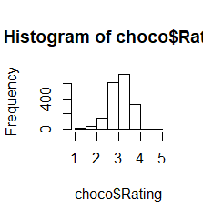

Rating Histogram

2. Do ratings depend on the cacao percentage of a chocolate bar?

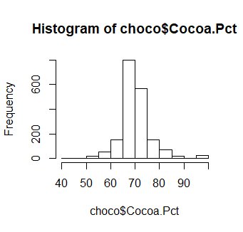

Percentage Histogram